# 広島県 (議員定数：7 → 6)

アルゴリズムによる衆議院小選挙区の区割り改定案

ALARM Japan プロジェクトチーム  
2022/04/23

**広島県**

人口： 2,751,969 人（2020年）

|  | 現行 | アルゴリズムの提案 市区町村の分割無し | アルゴリズムの提案 最大市区町村の分割可 |
| --- | --- | --- | --- |
| **1票の格差** |  |  |  |
| 県内較差 | 1.725 | 1.162 | 1.147 |
| 改善率 | - | 77.6% | 79.7% |
| **選挙区の状況** |  |  |  |
| 選挙区数 | 7 | 6 | 6 |
| 市区町村の分割 | 4<sup>a</sup> | 0 | 1<sup>b</sup> |
| 郡の分割 | 0 | 0 | 0 |
| 広域連携地域の分割 | 3<sup>c</sup> | 3<sup>c</sup> | 3<sup>c</sup> |

<sup>a</sup> 江田島市、尾道市、東広島市、三原市  
<sup>b</sup> 福山市  
<sup>c</sup> 広島広域都市圏、備後圏域、広島中央地域連携中枢都市圏

# 現行の区割り

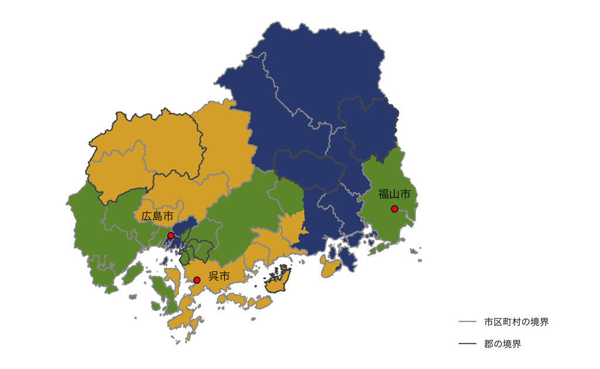

# アルゴリズムの提案

アルゴリズムが提案した5,000案のうち、一票の格差が最小のもの

### 市区町村を分割しない区割り案

一票の格差 : 1.162

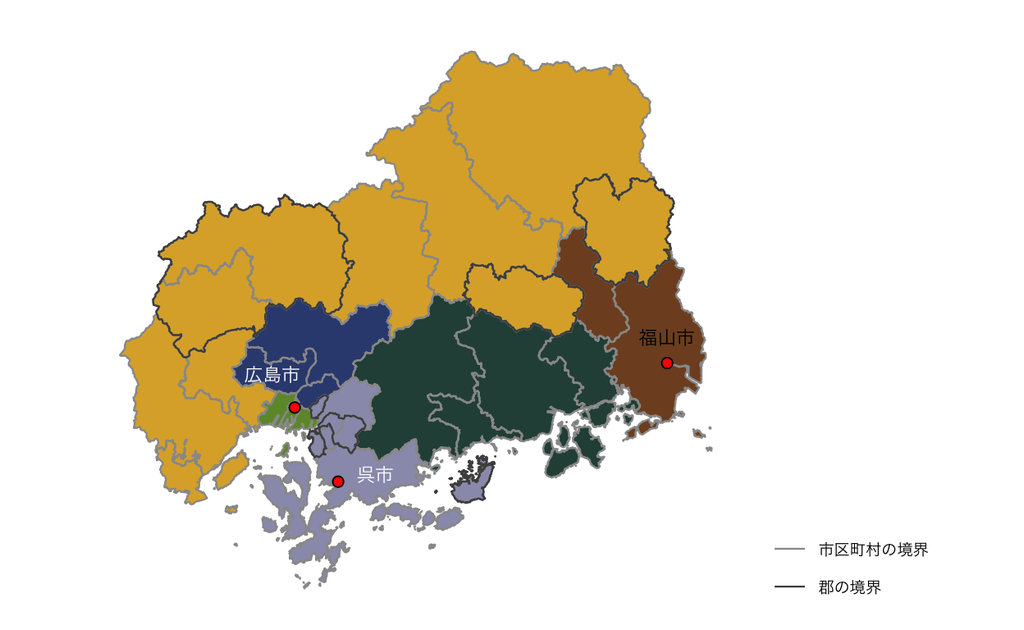

### 最大市区町村の分割を許容する区割り案

人口が最大の市区町村 : 福山市

一票の格差 : 1.147

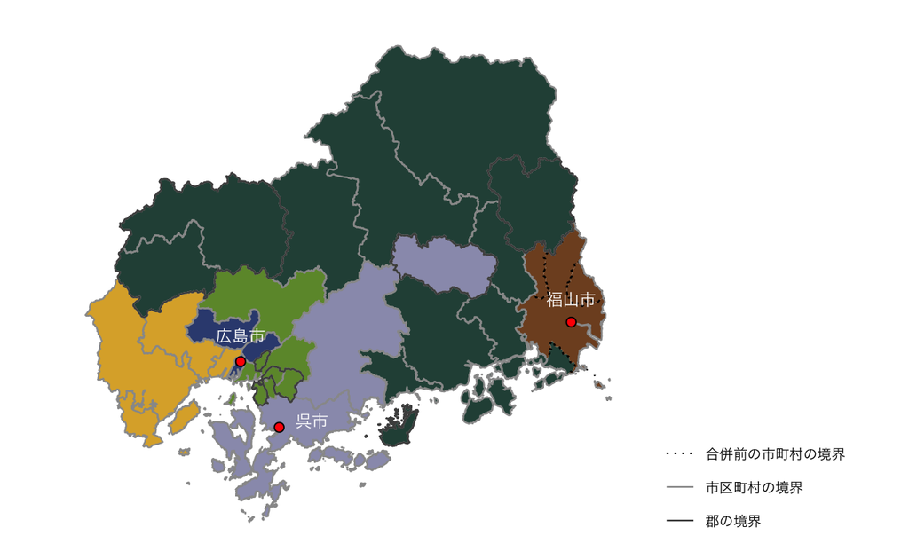

# 共起分析

- アルゴリズム設定
  - 市区町村の分割無し
  - 飛び地を含む案を棄却
  - 一票の格差が下位10％の案を抽出
- 読み取り方  
  地図上の市区町村の色が
  - 同じ → 同じ選挙区に属する傾向が強い
  - 同じ かつ 濃い → 隣接する市区町村と同じ選挙区に属する傾向が強い

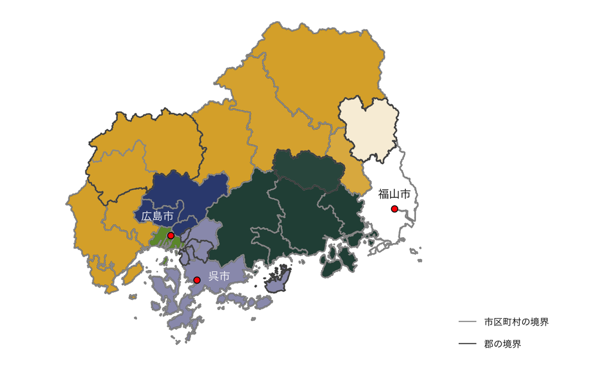

# アルゴリズム設定

- 各選挙区の人口 : (県内の日本人人口 / 選挙区数) ±10%
  - サンプリング効率が80%~100%となるように調節
- 市区町村分割を許容しない案、及び日本人人口が最大の市（政令指定都市の行政区を除く）の分割を許容する案の2種類を作成
  - 最大市区町村を分割する際は、平成の大合併以前の市区町村界に基づく
  - 旧市区町村単位の人口（総人口-外国人人口）は、合併後の市区町村の人口（総人口-外国人人口）と旧市区町村単位の日本人人口を元に推計
- 郡の分割は、現行の区割りにて分割されている場合のみ許容
- 離島は、航路で結ばれている本土の市区町村と同一の選挙区にする
- 市区町村分割を許容しない案、最大市区町村の分割を許容する案をそれぞれ75,000作成
- 以下の案を棄却し有効な案を選定
  - 飛び地が生じる案
  - 市区町村が3つ以上の選挙区に分割される案
- 有効な案の中から5,000の案を無作為に抽出

### 県特有の設定

- 尾道市浦崎町は厳密には飛び地とみなすこともできるが、現行の区割りでは飛び地として扱われていないため、本プロジェクトでも飛び地として扱わない。

# データとプログラム

- [**Dataverse** : シュミレーションデータ](https://doi.org/10.7910/DVN/Z9UKSH)
- [**GitHub** : プログラム・コード](https://github.com/alarm-redist/japan)